# Bikeshare: Meta file

Minh-Ngoc Huynh and Alexis Alexander

We’re just looking at September 2023 for right now. we want to know at a specific instance in time, how many riders there are? Now obviously the amount of people riding will be different for every day, so I think we may be looking for an average only.

(Still need to add a map into the plot. Will do so soon.)

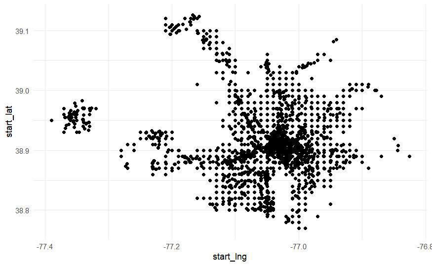

```r
library(tidyverse)
library(janitor)
library(here)
library(openmeteo)

rm(list = ls())

bikes <- read_csv("data_raw/202309-capitalbikeshare-tripdata.csv", show_col_types = FALSE) %>% clean_names()
DCWeather<- weather_history(c(38.9072, 77.0369), start= "2023-09-01", end= "2023-09-30", hourly = c("apparent_temperature", "windspeed_10m", "precipitation", "rain"))

ggplot(data = bikes, mapping = aes(x = start_lng, y = start_lat)) +geom_point()
```

# Plots Defaults

For consistency:

```r
theme_set(theme_minimal())
```

for every start time there is +1, end time is -1, and then create a cumlative sum on the rider column

# Rider vs. Time

To track active riders over time, we’ll break each observation into

- “ride start”, which increases active riders by one
- “ride end”, which decreases active riders by one

Starting to manipulate the data using a small data set

```r
bikes_in_time = bikes |>
 # slice_head(n=100) |>
  pivot_longer(
    cols = c(started_at, ended_at),
    names_to = "start_end",
    values_to = "t") |>
  arrange(t) |>
  mutate(rider_delta = (start_end == "started_at")*2-1) |> # Results in +/- 1
  mutate(riders=cumsum(rider_delta)) |>
  relocate(t, start_end, riders, .after = rideable_type)
```

### Full Month

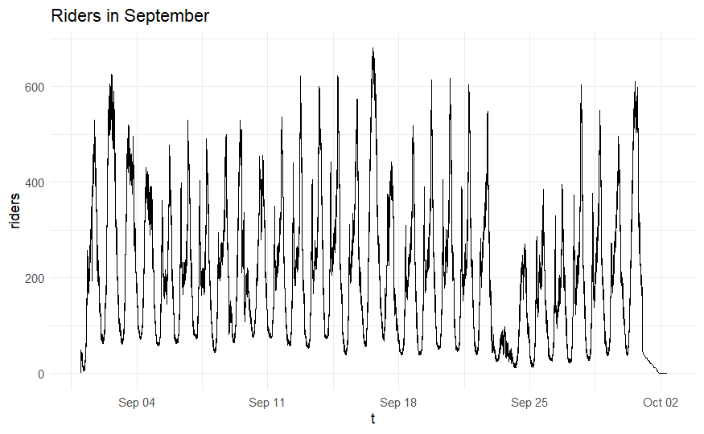

```r
bikes_in_time %>%
   # slice_sample(prop = .01) |> # Removing some of the data on the plot
  ggplot(aes(t,riders)) +
  geom_line() +
  ggtitle("Riders in September")
```

### Filtering for One Day

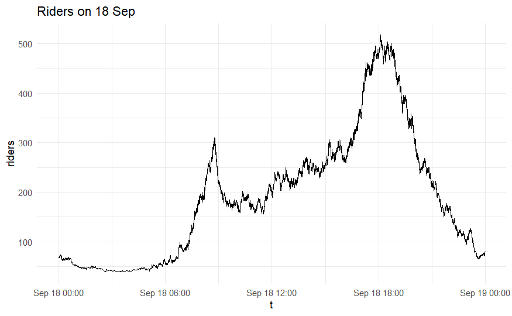

```r
bikes_in_time %>%
  filter(day(t) == 18) %>%
  ggplot(aes(t,riders)) +
  geom_line() +
  ggtitle("Riders on 18 Sep")
```

### Splitting the Graph from Day 1 to Day 30

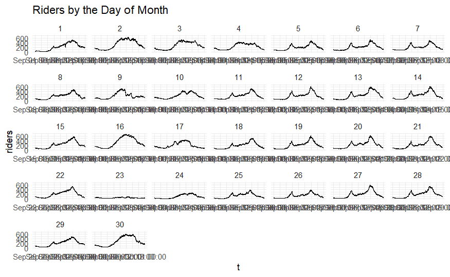

```r
bikes_in_time %>%
  filter(month(t) == 9) %>%
  ggplot(aes(t,riders)) +
  geom_line() +
  facet_wrap(~mday(t), scales = "free_x", ncol=7) +
  ggtitle("Riders by the Day of Month")
```

### Looking at the Weekday

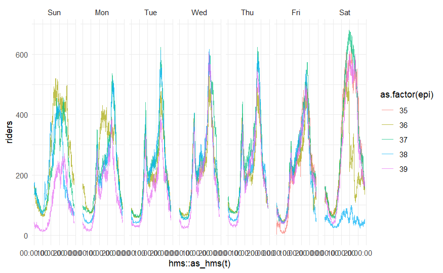

```r
bikes_in_time %>%
  filter(month(t) == 9) %>%
  mutate(epi=epiweek(t), wd=wday(t,label=TRUE, week_start = 7)) %>%
  ggplot(aes(hms::as_hms(t), riders,color=as.factor(epi))) +
  geom_line(alpha = 0.7) +
  facet_wrap(~wd, scales = "free_x", ncol=7)
```

```r
  ggtitle("Riders in September Based on Weekday")
```

```
$title
[1] "Riders in September Based on Weekday"

attr(,"class")
[1] "labels"
```

### Is the pattern similar between electric and classic bikes?

We will need to recompute the cumsum by group (in addition to overall): - A cumlative sum by group

```r
bikes_type = bikes_in_time %>%
  mutate(type_riders=cumsum(rider_delta), .by=rideable_type) %>%
  relocate(type_riders,.after=riders)
```

```r
bikes_type %>%
  filter(month(t)==9) %>%
  ggplot(aes(t,type_riders,color=rideable_type))+
  geom_line()+
  facet_wrap(~mday(t), scales = "free_x", ncol=7)
```

[output not shown]

Next task: Look at whether they are a member or a casual rider? Look at that comparison as well To find if they are casual or a member, we can use some weather information to sort out people who visit vs live in DC.

```r
startBikes = bikes |>
  select(rideable_type, member_casual, contains("start"), ride_id) |>
  mutate(start_stop = "start") |>
  rename(t = started_at, station_name = start_station_name, station_id = start_station_id, lat = start_lat, lng = start_lng)

endBikes = bikes |>
  select(rideable_type, member_casual, contains("end"), ride_id) |>
  mutate(start_stop = "stop") |> ##making new variable so we know what this data is when we merge
  rename(t = ended_at, station_name = end_station_name, station_id = end_station_id, lat = end_lat, lng = end_lng)

distanceBiked = bind_rows(startBikes, endBikes)
```

Joining with categorial data. You can have rolling helper (which matches the closest data points), the ==, the <=, >= and etc etc.